# Project 3 - Cars4U Project

**Description** (copied from assignment)

**Background & Context**

There is a huge demand for used cars in the Indian Market today. As sales of new cars have slowed down in the recent past, the pre-owned car market has continued to grow over the past years and is larger than the new car market now. Cars4U is a budding tech start-up that aims to find footholes in this market.

In 2018-19, while new car sales were recorded at 3.6 million units, around 4 million second-hand cars were bought and sold. There is a slowdown in new car sales and that could mean that the demand is shifting towards the pre-owned market. In fact, some car sellers replace their old cars with pre-owned cars instead of buying new ones. Unlike new cars, where price and supply are fairly deterministic and managed by OEMs (Original Equipment Manufacturer / except for dealership level discounts which come into play only in the last stage of the customer journey), used cars are very different beasts with huge uncertainty in both pricing and supply. Keeping this in mind, the pricing scheme of these used cars becomes important in order to grow in the market.

As a senior data scientist at Cars4U, you have to come up with a pricing model that can effectively predict the price of used cars and can help the business in devising profitable strategies using differential pricing. For example, if the business knows the market price, it will never sell anything below it.

**Objective**

1. Explore and visualize the dataset.
2. Build a linear regression model to predict the prices of used cars.
3. Generate a set of insights and recommendations that will help the business.

**Data Dictionary**

1. S.No. : Serial Number
2. Name : Name of the car which includes Brand name and Model name
3. Location : The location in which the car is being sold or is available for purchase Cities
4. Year : Manufacturing year of the car
5. Kilometers_driven : The total kilometers driven in the car by the previous owner(s) in KM.
6. Fuel_Type : The type of fuel used by the car. (Petrol, Diesel, Electric, CNG, LPG)
7. Transmission : The type of transmission used by the car. (Automatic / Manual)
8. Owner : Type of ownership
9. Mileage : The standard mileage offered by the car company in kmpl or km/kg
10. Engine : The displacement volume of the engine in CC.
11. Power : The maximum power of the engine in bhp.
12. Seats : The number of seats in the car.
13. New_Price : The price of a new car of the same model in INR Lakhs.(1 Lakh = 100, 000)
14. Price : The price of the used car in INR Lakhs (1 Lakh = 100, 000)

# 1 - Load Packages and Read in the Dataset

```python
# Import necessary libraries
import numpy as np
import pandas as pd
import matplotlib.pyplot as plt
import seaborn as sns

import warnings

warnings.filterwarnings("ignore")

# To enable plotting graphs in Jupyter notebook
%matplotlib inline

# To build linear regression_model
from sklearn.linear_model import LinearRegression

# To check model performance
from sklearn.metrics import mean_absolute_error, mean_squared_error, r2_score

# to make Python code more structured
%load_ext nb_black

# Remove limit from displayed columns and rows.
pd.set_option("display.max_columns", None)
pd.set_option("display.max_rows", 200)
```

```python
# Load the data into pandas dataframe
cars = pd.read_csv("used_cars_data.csv")
```

# 2 - Data Preprocessing (Part 1 of 2)

## 2.1 - Check the first and last 10 rows of the dataset as well as random 10 rows

```python
# first 10 rows
cars.head(10)
```

|  | S.No. | Name | Location | Year | Kilometers_Driven | Fuel_Type | Transmission | Owner_Type | Mileage | Engine | Power | Seats | New_Price | Price |
| --- | --- | --- | --- | --- | --- | --- | --- | --- | --- | --- | --- | --- | --- | --- |
| 0 | 0 | Maruti Wagon R LXI CNG | Mumbai | 2010 | 72000 | CNG | Manual | First | 26.6 km/kg | 998 CC | 58.16 bhp | 5.0 | NaN | 1.75 |
| 1 | 1 | Hyundai Creta 1.6 CRDi SX Option | Pune | 2015 | 41000 | Diesel | Manual | First | 19.67 kmpl | 1582 CC | 126.2 bhp | 5.0 | NaN | 12.50 |
| 2 | 2 | Honda Jazz V | Chennai | 2011 | 46000 | Petrol | Manual | First | 18.2 kmpl | 1199 CC | 88.7 bhp | 5.0 | 8.61 Lakh | 4.50 |
| 3 | 3 | Maruti Ertiga VDI | Chennai | 2012 | 87000 | Diesel | Manual | First | 20.77 kmpl | 1248 CC | 88.76 bhp | 7.0 | NaN | 6.00 |
| 4 | 4 | Audi A4 New 2.0 TDI Multitronic | Coimbatore | 2013 | 40670 | Diesel | Automatic | Second | 15.2 kmpl | 1968 CC | 140.8 bhp | 5.0 | NaN | 17.74 |
| 5 | 5 | Hyundai EON LPG Era Plus Option | Hyderabad | 2012 | 75000 | LPG | Manual | First | 21.1 km/kg | 814 CC | 55.2 bhp | 5.0 | NaN | 2.35 |
| 6 | 6 | Nissan Micra Diesel XV | Jaipur | 2013 | 86999 | Diesel | Manual | First | 23.08 kmpl | 1461 CC | 63.1 bhp | 5.0 | NaN | 3.50 |
| 7 | 7 | Toyota Innova Crysta 2.8 GX AT 8S | Mumbai | 2016 | 36000 | Diesel | Automatic | First | 11.36 kmpl | 2755 CC | 171.5 bhp | 8.0 | 21 Lakh | 17.50 |
| 8 | 8 | Volkswagen Vento Diesel Comfortline | Pune | 2013 | 64430 | Diesel | Manual | First | 20.54 kmpl | 1598 CC | 103.6 bhp | 5.0 | NaN | 5.20 |
| 9 | 9 | Tata Indica Vista Quadrajet LS | Chennai | 2012 | 65932 | Diesel | Manual | Second | 22.3 kmpl | 1248 CC | 74 bhp | 5.0 | NaN | 1.95 |

```python
# last 10 rows
cars.tail(10)
```

|  | S.No. | Name | Location | Year | Kilometers_Driven | Fuel_Type | Transmission | Owner_Type | Mileage | Engine | Power | Seats | New_Price | Price |
| --- | --- | --- | --- | --- | --- | --- | --- | --- | --- | --- | --- | --- | --- | --- |
| 7243 | 7243 | Renault Duster 85PS Diesel RxL | Chennai | 2015 | 70000 | Diesel | Manual | First | 19.87 kmpl | 1461 CC | 83.8 bhp | 5.0 | NaN | NaN |
| 7244 | 7244 | Chevrolet Aveo 1.4 LS | Pune | 2009 | 45463 | Petrol | Manual | First | 14.49 kmpl | 1399 CC | 92.7 bhp | 5.0 | NaN | NaN |
| 7245 | 7245 | Honda Amaze S i-Vtech | Kochi | 2015 | 44776 | Petrol | Manual | First | 18.0 kmpl | 1198 CC | 86.7 bhp | 5.0 | NaN | NaN |
| 7246 | 7246 | Hyundai Grand i10 AT Asta | Coimbatore | 2016 | 18242 | Petrol | Automatic | First | 18.9 kmpl | 1197 CC | 82 bhp | 5.0 | NaN | NaN |
| 7247 | 7247 | Hyundai EON D Lite Plus | Coimbatore | 2015 | 21190 | Petrol | Manual | First | 21.1 kmpl | 814 CC | 55.2 bhp | 5.0 | NaN | NaN |
| 7248 | 7248 | Volkswagen Vento Diesel Trendline | Hyderabad | 2011 | 89411 | Diesel | Manual | First | 20.54 kmpl | 1598 CC | 103.6 bhp | 5.0 | NaN | NaN |
| 7249 | 7249 | Volkswagen Polo GT TSI | Mumbai | 2015 | 59000 | Petrol | Automatic | First | 17.21 kmpl | 1197 CC | 103.6 bhp | 5.0 | NaN | NaN |
| 7250 | 7250 | Nissan Micra Diesel XV | Kolkata | 2012 | 28000 | Diesel | Manual | First | 23.08 kmpl | 1461 CC | 63.1 bhp | 5.0 | NaN | NaN |
| 7251 | 7251 | Volkswagen Polo GT TSI | Pune | 2013 | 52262 | Petrol | Automatic | Third | 17.2 kmpl | 1197 CC | 103.6 bhp | 5.0 | NaN | NaN |
| 7252 | 7252 | Mercedes-Benz E-Class 2009-2013 E 220 CDI Avan... | Kochi | 2014 | 72443 | Diesel | Automatic | First | 10.0 kmpl | 2148 CC | 170 bhp | 5.0 | NaN | NaN |

```python
# random 10 rows
np.random.seed(1)
cars.sample(n=10)
```

|  | S.No. | Name | Location | Year | Kilometers_Driven | Fuel_Type | Transmission | Owner_Type | Mileage | Engine | Power | Seats | New_Price | Price |
| --- | --- | --- | --- | --- | --- | --- | --- | --- | --- | --- | --- | --- | --- | --- |
| 2397 | 2397 | Ford EcoSport 1.5 Petrol Trend | Kolkata | 2016 | 21460 | Petrol | Manual | First | 17.0 kmpl | 1497 CC | 121.36 bhp | 5.0 | 9.47 Lakh | 6.00 |
| 3777 | 3777 | Maruti Wagon R VXI 1.2 | Kochi | 2015 | 49818 | Petrol | Manual | First | 21.5 kmpl | 1197 CC | 81.80 bhp | 5.0 | 5.44 Lakh | 4.11 |
| 4425 | 4425 | Ford Endeavour 4x2 XLT | Hyderabad | 2007 | 130000 | Diesel | Manual | First | 13.1 kmpl | 2499 CC | 141 bhp | 7.0 | NaN | 6.00 |
| 3661 | 3661 | Mercedes-Benz E-Class E250 CDI Avantgrade | Coimbatore | 2016 | 39753 | Diesel | Automatic | First | 13.0 kmpl | 2143 CC | 201.1 bhp | 5.0 | NaN | 35.28 |
| 4514 | 4514 | Hyundai Xcent 1.2 Kappa AT SX Option | Kochi | 2016 | 45560 | Petrol | Automatic | First | 16.9 kmpl | 1197 CC | 82 bhp | 5.0 | NaN | 6.34 |
| 599 | 599 | Toyota Innova Crysta 2.8 ZX AT | Coimbatore | 2019 | 40674 | Diesel | Automatic | First | 11.36 kmpl | 2755 CC | 171.5 bhp | 7.0 | 28.05 Lakh | 24.82 |
| 186 | 186 | Mercedes-Benz E-Class E250 CDI Avantgrade | Bangalore | 2014 | 37382 | Diesel | Automatic | First | 13.0 kmpl | 2143 CC | 201.1 bhp | 5.0 | NaN | 32.00 |
| 305 | 305 | Audi A6 2011-2015 2.0 TDI Premium Plus | Kochi | 2014 | 61726 | Diesel | Automatic | First | 17.68 kmpl | 1968 CC | 174.33 bhp | 5.0 | NaN | 20.77 |
| 4582 | 4582 | Hyundai i20 1.2 Magna | Kolkata | 2011 | 36000 | Petrol | Manual | First | 18.5 kmpl | 1197 CC | 80 bhp | 5.0 | NaN | 2.50 |
| 5434 | 5434 | Honda WR-V Edge Edition i-VTEC S | Kochi | 2019 | 13913 | Petrol | Manual | First | 17.5 kmpl | 1199 CC | 88.7 bhp | 5.0 | 9.36 Lakh | 8.20 |

**Observations:**

- Fuel_Type, Transmission, Seats are all categorical variables. If Owner_Type has any other values besides "First" it could be a categorical variable as well.
- Units need to be removed from Mileage, Engine, Power, and New_Price.

## 2.2 - Check the shape of the data

```python
cars.shape
```

```
(7253, 14)
```

## 2.3 - Check the datatypes and row counts for each column

```python
cars.info()
```

```
<class 'pandas.core.frame.DataFrame'>
RangeIndex: 7253 entries, 0 to 7252
Data columns (total 14 columns):
 #   Column             Non-Null Count  Dtype
---  ------             --------------  -----
 0   S.No.              7253 non-null   int64
 1   Name               7253 non-null   object
 2   Location           7253 non-null   object
 3   Year               7253 non-null   int64
 4   Kilometers_Driven  7253 non-null   int64
 5   Fuel_Type          7253 non-null   object
 6   Transmission       7253 non-null   object
 7   Owner_Type         7253 non-null   object
 8   Mileage            7251 non-null   object
 9   Engine             7207 non-null   object
 10  Power              7207 non-null   object
 11  Seats              7200 non-null   float64
 12  New_Price          1006 non-null   object
 13  Price              6019 non-null   float64
dtypes: float64(2), int64(3), object(9)
memory usage: 793.4+ KB
```

**Observations:**

- The following have null values that need to be dealt with: Mileage, Engine, Power, Seats, New_Price, and Price.
- Confirming from earlier observation that Fuel_Type, Transmission, Owner_Type, and Seats need to be converted to categorical variables.
- Mileage, Power, and New_Price need to be converted to a float once units are removed.
- Engine should be an integer once units are removed.

## 2.4 - Drop Values

```python
# S.No. is an identifier - not really useful for current project
cars.drop(["S.No."], axis=1, inplace=True)

# New Price is missing over 50% of values (advice per Project Forum)
cars.drop(["New_Price"], axis=1, inplace=True)
```

## 2.5 - Fix Mileage - Remove Units, Convert to Float, Treat Missing Values

```python
# Remove units for Mileage and convert to float - possible units are km/kg and kmpl
for index in cars["Mileage"].index:
    if str(cars["Mileage"][index]).endswith("g"):
        cars["Mileage"][index] = str(cars["Mileage"][index]).replace("km/kg", "")
    elif str(cars["Mileage"][index]).endswith("l"):
        cars["Mileage"][index] = str(cars["Mileage"][index]).replace("kmpl", "")

cars["Mileage"] = cars["Mileage"].astype("float")
```

```python
# confirming changes to Mileage were successful
cars["Mileage"]
```

```
0       26.60
1       19.67
2       18.20
3       20.77
4       15.20
        ...
7248    20.54
7249    17.21
7250    23.08
7251    17.20
7252    10.00
Name: Mileage, Length: 7253, dtype: float64
```

```python
# Replace missing values with median
cars["Mileage"].fillna(cars["Mileage"].median(), inplace=True)

# Double-check change to Mileage took place
cars["Mileage"].isnull().sum()
```

```
0
```

## 2.6 - Fix Power - Remove Units, Convert to Float, Treat Missing Values

```python
# Remove units for Power - possible units are bhp
for index in cars["Power"].index:
    if str(cars["Power"][index]).endswith("p"):
        cars["Power"][index] = str(cars["Power"][index]).replace("bhp", "")

# Convert nulls and blanks to NaN
for index in cars["Power"].index:
    if "null" in str(cars["Power"][index]):
        cars["Power"][index] = np.nan
```

```python
# confirming changes to "Power" were successful
cars["Power"]
```

```
0       58.16
1       126.2
2        88.7
3       88.76
4       140.8
         ...
7248    103.6
7249    103.6
7250     63.1
7251    103.6
7252      170
Name: Power, Length: 7253, dtype: object
```

```python
# Checking how many nulls are left
cars["Power"].isnull().sum()
```

```
175
```

```python
# CODE IDEA NOT WORKING - commenting out

# Create a lookup table of unique values for Name, Year, and Power from dataframe
# Trying to figure out Power from other matching cars with same name and year
# power_lookup = cars[["Name", "Year", "Power"]].copy()
# power_lookup.dropna(inplace=True)
# power_lookup = power_lookup.drop_duplicates()

# Retrieve value of Power for cars dataframe based on corresponding
# Name, Year, Power in lookup table
# for index in cars[cars["Power"].isnull() == True].index:
#    car_name = cars["Name"][index]
#    car_year = cars["Year"][index]

#    for index2 in power_lookup.index:
#        if power_lookup["Name"][index2] == car_name:
#            if power_lookup["Year"][index2] == car_year:
#                cars["Power"][index] = power_lookup["Power"][index2]

# Figure out how many remaining nulls are there
# cars["Power"].isnull().sum()
```

```python
# Fill remaining null values with overall Power median
cars["Power"].fillna(cars["Power"].median(), inplace=True)

# Double-check change to Power took place
cars["Power"].isnull().sum()
```

```
0
```

```python
# Convert Power to float
cars["Power"] = cars["Power"].astype("float")
cars.info()  # confirming change took place
```

```
<class 'pandas.core.frame.DataFrame'>
RangeIndex: 7253 entries, 0 to 7252
Data columns (total 12 columns):
 #   Column             Non-Null Count  Dtype
---  ------             --------------  -----
 0   Name               7253 non-null   object
 1   Location           7253 non-null   object
 2   Year               7253 non-null   int64
 3   Kilometers_Driven  7253 non-null   int64
 4   Fuel_Type          7253 non-null   object
 5   Transmission       7253 non-null   object
 6   Owner_Type         7253 non-null   object
 7   Mileage            7253 non-null   float64
 8   Engine             7207 non-null   object
 9   Power              7253 non-null   float64
 10  Seats              7200 non-null   float64
 11  Price              6019 non-null   float64
dtypes: float64(4), int64(2), object(6)
memory usage: 680.1+ KB
```

## 2.7 - Fix Engine - Remove Units, Convert to Integer, Treat Missing Values

```python
# Remove units for Engine and convert to integer - possible units are CC
for index in cars["Engine"].index:
    if str(cars["Engine"][index]).endswith("C"):
        cars["Engine"][index] = str(cars["Engine"][index]).replace("CC", "")
```

```python
# Treat missing values
# Fill remaining null values with overall Power median
cars["Engine"].fillna(cars["Engine"].median(), inplace=True)

# Double-check change to Power took place
cars["Engine"].isnull().sum()
```

```
0
```

```python
# Convert Engine to Integer
cars["Engine"] = cars["Engine"].astype("int")
cars.info()  # confirming change took place
```

```
<class 'pandas.core.frame.DataFrame'>
RangeIndex: 7253 entries, 0 to 7252
Data columns (total 12 columns):
 #   Column             Non-Null Count  Dtype
---  ------             --------------  -----
 0   Name               7253 non-null   object
 1   Location           7253 non-null   object
 2   Year               7253 non-null   int64
 3   Kilometers_Driven  7253 non-null   int64
 4   Fuel_Type          7253 non-null   object
 5   Transmission       7253 non-null   object
 6   Owner_Type         7253 non-null   object
 7   Mileage            7253 non-null   float64
 8   Engine             7253 non-null   int64
 9   Power              7253 non-null   float64
 10  Seats              7200 non-null   float64
 11  Price              6019 non-null   float64
dtypes: float64(4), int64(3), object(5)
memory usage: 680.1+ KB
```

## 2.8 - Fix Seats - Treat Missing Values

```python
cars["Seats"] = cars["Seats"].astype("str")
cars["Seats"].fillna("Missing", inplace=True)

# Double-check changes to Engine took place
cars["Seats"].isnull().sum()
```

```
0
```

## 2.9 - Fix Price - Treat Missing Values

```python
# CODE IDEA NOT WORKING - commenting out

# Create a lookup table of unique values for Name, Year, and Price from dataframe
# Trying to figure out Price from other matching cars with same name and year
# price_lookup = cars[["Name", "Year", "Price"]].copy()
# price_lookup.dropna(inplace=True)
# price_lookup = price_lookup.drop_duplicates()

# Retrieve value of Price for cars dataframe based on corresponding
# Name, Year, Price in lookup table
# for index in cars[cars["Price"].isnull() == True].index:
#    car_name = cars["Name"][index]
#    car_year = cars["Year"][index]

#    for index2 in price_lookup.index:
#        if price_lookup["Name"][index2] == car_name:
#            if price_lookup["Year"][index2] == car_year:
#                cars["Price"][index] = price_lookup["Price"][index2]

# Figure out how many remaining nulls are there
# cars["Price"].isnull().sum()
```

```python
# Fill missing values with median
cars["Price"].fillna(cars["Price"].median(), inplace=True)

# Double-check changes to Engine took place
cars["Price"].isnull().sum()
```

```
0
```

```python
# Double-check changes to "Price" took place
cars["Price"]
```

```
0        1.75
1       12.50
2        4.50
3        6.00
4       17.74
        ...
7248     5.64
7249     5.64
7250     5.64
7251     5.64
7252     5.64
Name: Price, Length: 7253, dtype: float64
```

```python
# Check to see if there are any more missing values to treat
cars.info()
```

```
<class 'pandas.core.frame.DataFrame'>
RangeIndex: 7253 entries, 0 to 7252
Data columns (total 12 columns):
 #   Column             Non-Null Count  Dtype
---  ------             --------------  -----
 0   Name               7253 non-null   object
 1   Location           7253 non-null   object
 2   Year               7253 non-null   int64
 3   Kilometers_Driven  7253 non-null   int64
 4   Fuel_Type          7253 non-null   object
 5   Transmission       7253 non-null   object
 6   Owner_Type         7253 non-null   object
 7   Mileage            7253 non-null   float64
 8   Engine             7253 non-null   int64
 9   Power              7253 non-null   float64
 10  Seats              7253 non-null   object
 11  Price              7253 non-null   float64
dtypes: float64(3), int64(3), object(6)
memory usage: 680.1+ KB
```

## 2.10 - Fix Name - Extract Brand and Model

```python
temp = cars["Name"].str.split(" ", n=1, expand=True)
temp.head()
```

|  | 0 | 1 |
| --- | --- | --- |
| 0 | Maruti | Wagon R LXI CNG |
| 1 | Hyundai | Creta 1.6 CRDi SX Option |
| 2 | Honda | Jazz V |
| 3 | Maruti | Ertiga VDI |
| 4 | Audi | A4 New 2.0 TDI Multitronic |

```python
cars["Brand"] = temp[0]
cars["Model"] = temp[1]
cars.drop(["Name"], axis=1, inplace=True)
```

# 3 - EDA

## 3.1 - Explore Summary of Data

```python
cars.describe(include="all").T
```

|  | count | unique | top | freq | mean | std | min | 25% | 50% | 75% | max |
| --- | --- | --- | --- | --- | --- | --- | --- | --- | --- | --- | --- |
| Location | 7253 | 11 | Mumbai | 949 | NaN | NaN | NaN | NaN | NaN | NaN | NaN |
| Year | 7253.0 | NaN | NaN | NaN | 2013.365366 | 3.254421 | 1996.0 | 2011.0 | 2014.0 | 2016.0 | 2019.0 |
| Kilometers_Driven | 7253.0 | NaN | NaN | NaN | 58699.063146 | 84427.720583 | 171.0 | 34000.0 | 53416.0 | 73000.0 | 6500000.0 |
| Fuel_Type | 7253 | 5 | Diesel | 3852 | NaN | NaN | NaN | NaN | NaN | NaN | NaN |
| Transmission | 7253 | 2 | Manual | 5204 | NaN | NaN | NaN | NaN | NaN | NaN | NaN |
| Owner_Type | 7253 | 4 | First | 5952 | NaN | NaN | NaN | NaN | NaN | NaN | NaN |
| Mileage | 7253.0 | NaN | NaN | NaN | 18.141586 | 4.561567 | 0.0 | 15.17 | 18.16 | 21.1 | 33.54 |
| Engine | 7253.0 | NaN | NaN | NaN | 1615.789742 | 593.475257 | 72.0 | 1198.0 | 1493.0 | 1968.0 | 5998.0 |
| Power | 7253.0 | NaN | NaN | NaN | 112.312448 | 52.922581 | 34.2 | 77.0 | 94.0 | 138.03 | 616.0 |
| Seats | 7253 | 10 | 5.0 | 6047 | NaN | NaN | NaN | NaN | NaN | NaN | NaN |
| Price | 7253.0 | NaN | NaN | NaN | 8.826235 | 10.293313 | 0.44 | 3.85 | 5.64 | 8.4 | 160.0 |
| Brand | 7253 | 33 | Maruti | 1444 | NaN | NaN | NaN | NaN | NaN | NaN | NaN |
| Model | 7253 | 2041 | XUV500 W8 2WD | 55 | NaN | NaN | NaN | NaN | NaN | NaN | NaN |

**Observations:**

## 3.2 - Univariate Analysis

```python
# Function copied from prior case study:
# Let us write a function that will help us create boxplot and histogram for any input numerical variable.
# This function takes the numerical column as the input and returns the boxplots and histograms for the variable.
def histogram_boxplot(feature, figsize=(15, 10), bins=None):
    """Boxplot and histogram combined
    feature: 1-d feature array
    figsize: size of fig (default (9,8))
    bins: number of bins (default None / auto)
    """
    sns.set(font_scale=2)  # setting the font scale for seaborn
    f2, (ax_box2, ax_hist2) = plt.subplots(
        nrows=2,  # Number of rows of the subplot grid=2
        sharex=True,  # x-axis will be shared among all subplots
        gridspec_kw={"height_ratios": (0.25, 0.75)},
        figsize=figsize,
    )  # creating the 2 subplots
    sns.boxplot(
        feature, ax=ax_box2, showmeans=True, color="red"
    )  # boxplot will be created and a star will indicate the mean value of the column
    sns.distplot(feature, kde=F, ax=ax_hist2, bins=bins) if bins else sns.distplot(
        feature, kde=False, ax=ax_hist2
    )  # For histogram
    ax_hist2.axvline(
        feature.mean(), color="g", linestyle="--"
    )  # Add mean to the histogram
    ax_hist2.axvline(
        feature.median(), color="black", linestyle="-"
    )  # Add median to the histogram
```

### 3.2.1 - Explore dependent variable Price

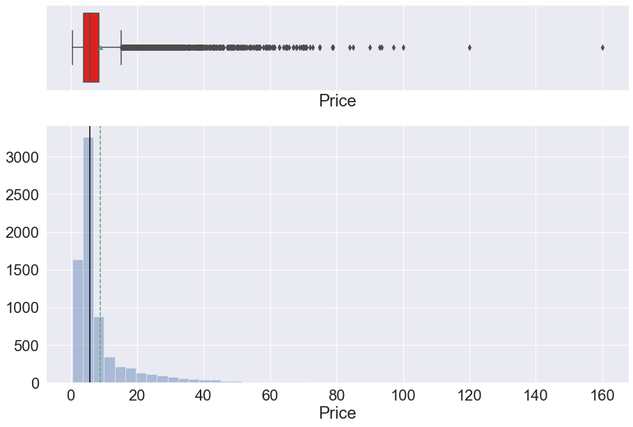

```python
histogram_boxplot(cars["Price"])
```

### 3.2.2 - Location

```python
# Function that creates barplots with percentage displayed over each category.
# Learned/customized from debrief of Project 1 Cardio Good Fitness


def perc_on_bar(plot, feature):
    total = len(feature)  # length of the column
    for p in ax.patches:
        percentage = "{:.1f}%".format(
            100 * p.get_height() / total
        )  # percentage of each class of the category
        x = p.get_x() + p.get_width() / 2 - 0.05
        y = p.get_y() + p.get_height()
        ax.annotate(percentage, (x, y), size=18)
    plt.show()
```

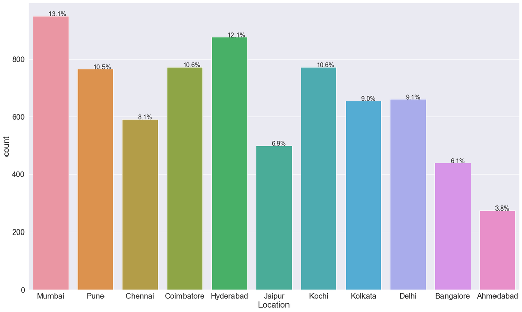

```python
plt.figure(figsize=(25, 15))
ax = sns.countplot(cars["Location"])
perc_on_bar(ax, cars["Location"])
```

**Observation:** The top 5 locations are Mumbai, Hyderabad, Coimbatore, Kochi, and Pune.

### 3.3.3 - Year

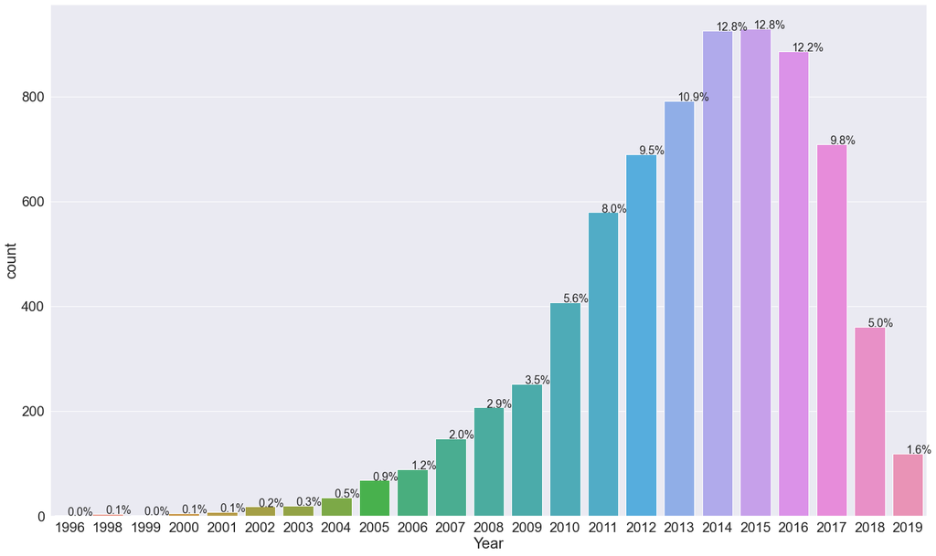

```python
plt.figure(figsize=(25, 15))
ax = sns.countplot(cars["Year"])
perc_on_bar(ax, cars["Year"])
```

**Observation:** The top 5 years are 2014, 2015, 2016, 2013, and 2017. The years range from 1996 to 2019.

### 3.3.4 - Kilometers_Driven

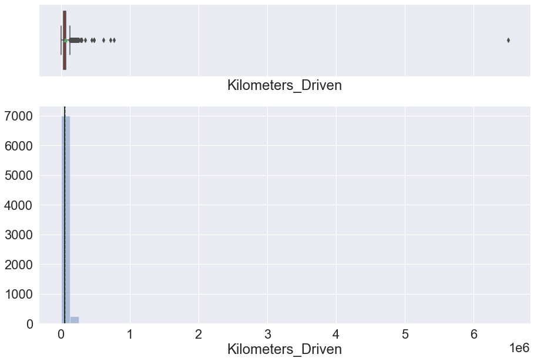

```python
histogram_boxplot(cars["Kilometers_Driven"])
```

**Observations:**

- Kilometers_Driven is right-skewed.
- There are many outliers.

### 3.3.5 - Fuel_Type

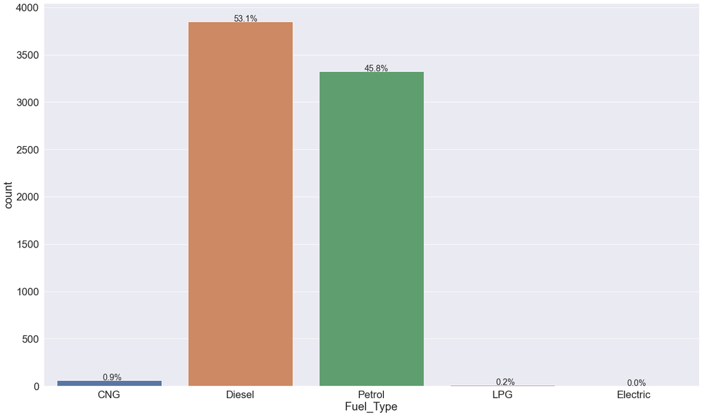

```python
plt.figure(figsize=(25, 15))
ax = sns.countplot(cars["Fuel_Type"])
perc_on_bar(ax, cars["Fuel_Type"])
```

**Observation:** Diesel and Petrol are by far the most prevalent fuel types.

### 3.3.6 - Transmission

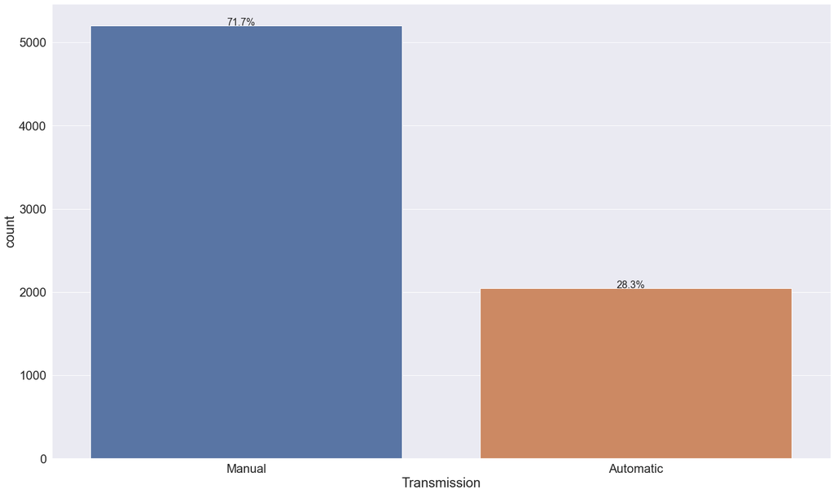

```python
plt.figure(figsize=(25, 15))
ax = sns.countplot(cars["Transmission"])
perc_on_bar(ax, cars["Transmission"])
```

**Observation**: Manual transmissions are most prevalent.

### 3.3.7 - Owner_Type

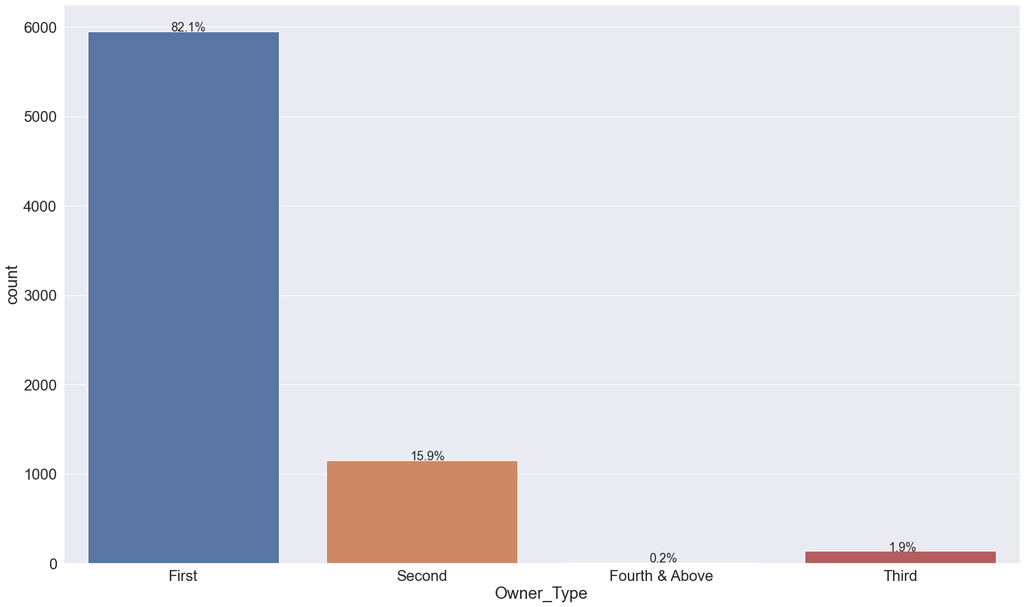

```python
plt.figure(figsize=(25, 15))
ax = sns.countplot(cars["Owner_Type"])
perc_on_bar(ax, cars["Owner_Type"])
```

**Observation:** Most owners are first-time car owners.

### 3.3.8 - Mileage

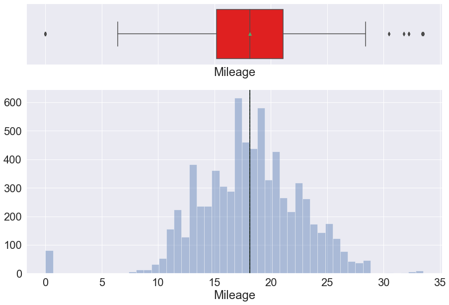

```python
histogram_boxplot(cars["Mileage"])
```

**Observation:** Mileage has outliers on both the left and right, but moreso on the right. That being said, distribution looks close to normal.

### 3.3.9 - Engine

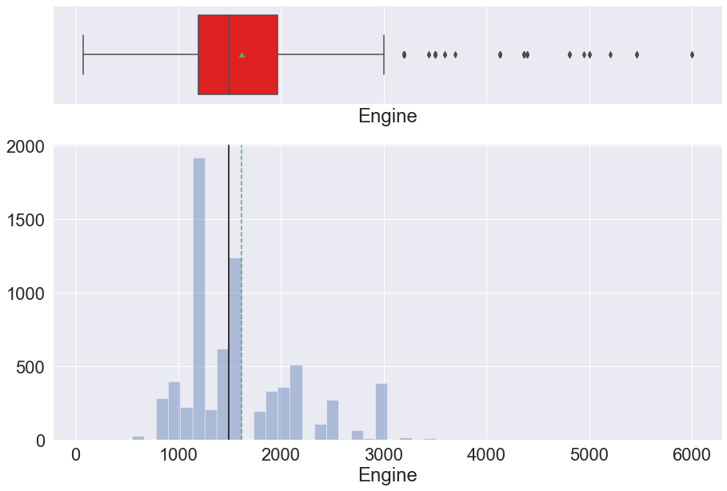

```python
histogram_boxplot(cars["Engine"])
```

**Observation:** Engine is right-skewed.

### 3.3.10 - Power

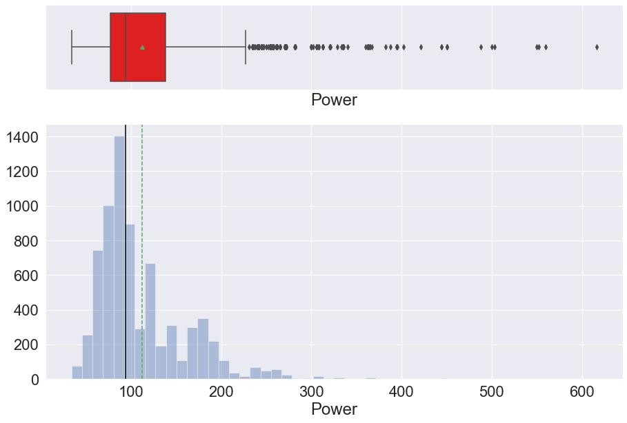

```python
histogram_boxplot(cars["Power"])
```

**Observation:** Power is right-skewed.

### 3.3.11 - Seats

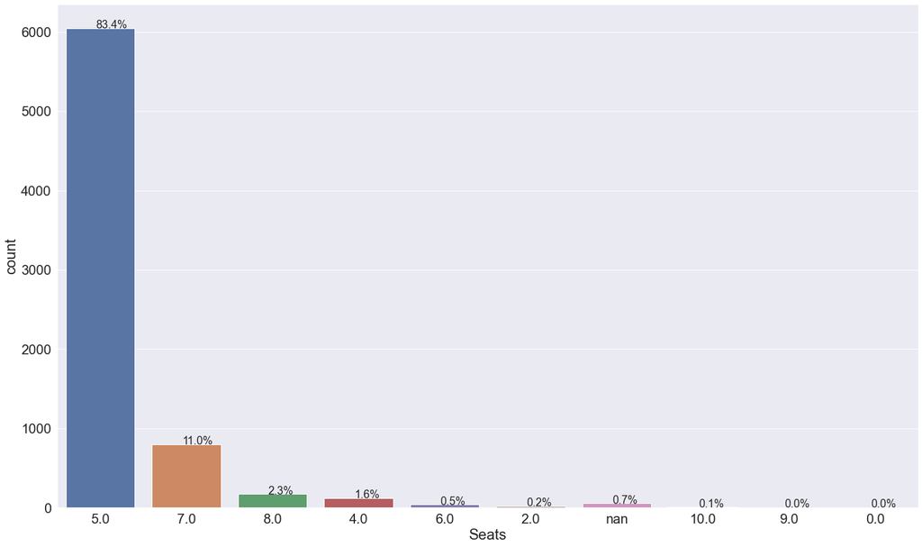

```python
plt.figure(figsize=(25, 15))
ax = sns.countplot(cars["Seats"])
perc_on_bar(ax, cars["Seats"])
```

**Observation:** 5.0 is by far the prevalent number of seats.

### 3.3.12 - Brands

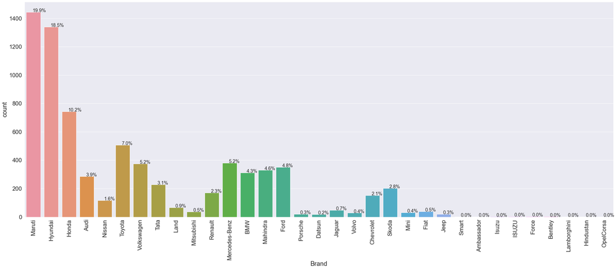

```python
plt.figure(figsize=(40, 15))
ax = sns.countplot(cars["Brand"])
ax.set_xticklabels(ax.get_xticklabels(), rotation=90)
perc_on_bar(ax, cars["Brand"])
```

## 3.3 - Bivariate and Multivariate Analyses

### 3.3.1 - Correlations

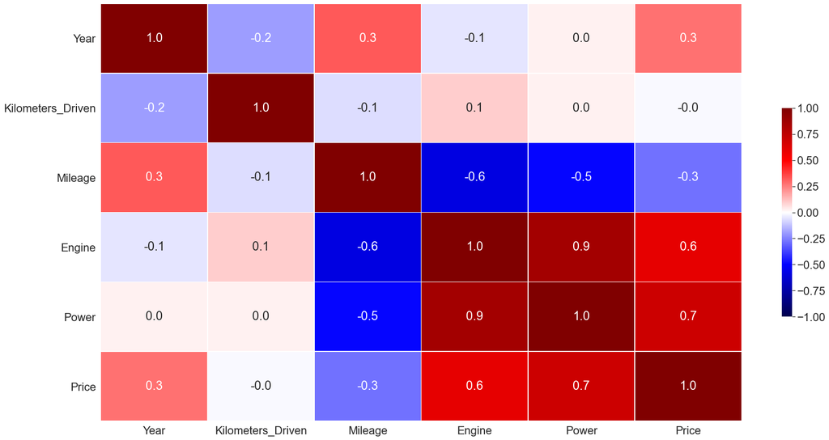

```python
# Taken/customized from a previous case study:
numeric_columns = cars.select_dtypes(include=np.number).columns.tolist()

corr = cars[numeric_columns].corr()  # sorting correlations w.r.t Price

# Set up the matplotlib figure
f, ax = plt.subplots(figsize=(28, 15))

# Draw the heatmap with the mask and correct aspect ratio
sns.heatmap(
    corr,
    cmap="seismic",
    annot=True,
    fmt=".1f",
    vmin=-1,
    vmax=1,
    center=0,
    square=False,
    linewidths=0.7,
    cbar_kws={"shrink": 0.5},
)
```

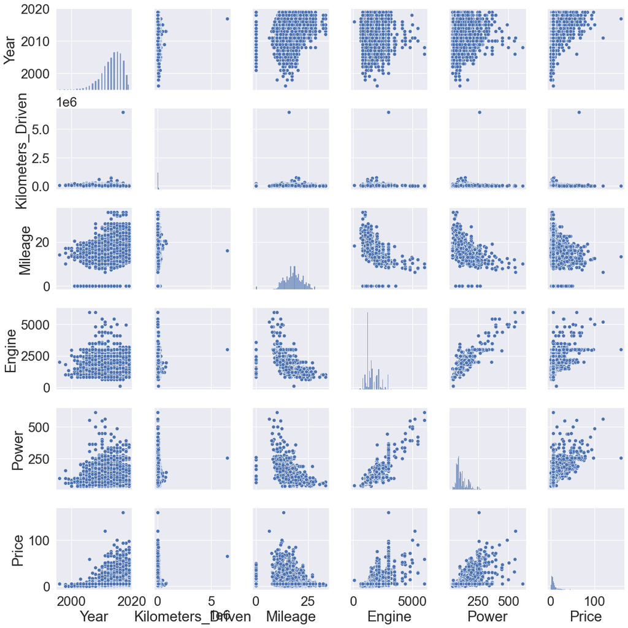

```python
sns.pairplot(data=cars)
plt.show()
```

**Observations:**

- High correlation exists between Price and Power, Price and Engine. Slight correlation exists between Price and Year.
- As would be expected, there is a high correlation between Power and Engine.
- Moderate negative correlation exists between Mileage and Power, and Mileage and Engine.

### 3.3.2 - Explore Variables Highly and Moderately Correlated with Price

#### 3.3.2.1 - Price vs. Power

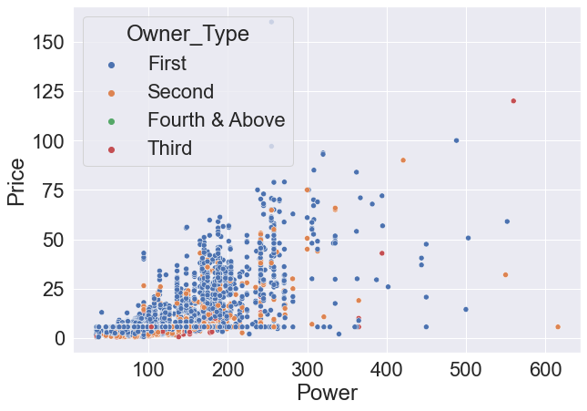

```python
# Explore relationship to Owner_Type between Power vs. Price
plt.figure(figsize=(10, 7))
sns.scatterplot(y="Price", x="Power", hue="Owner_Type", data=cars)
```

**Observations:**

- First and second-time owners cover the entire range of Price vs. Power.
- A small cluster of third-time owners cover the range from 100-200 bhp. These owners spent below 25 Lakh, close to the minimum price.

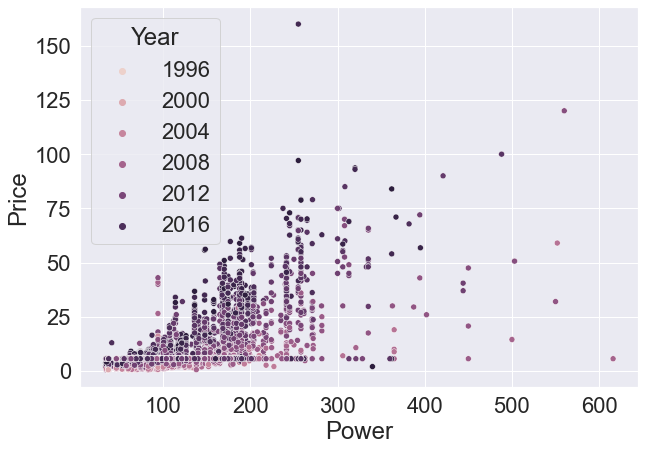

```python
# Explore relationship to Year between Power vs. Price
plt.figure(figsize=(10, 7))
sns.scatterplot(y="Price", x="Power", hue="Year", data=cars)
```

#### 3.3.2.2 - Price and Engine

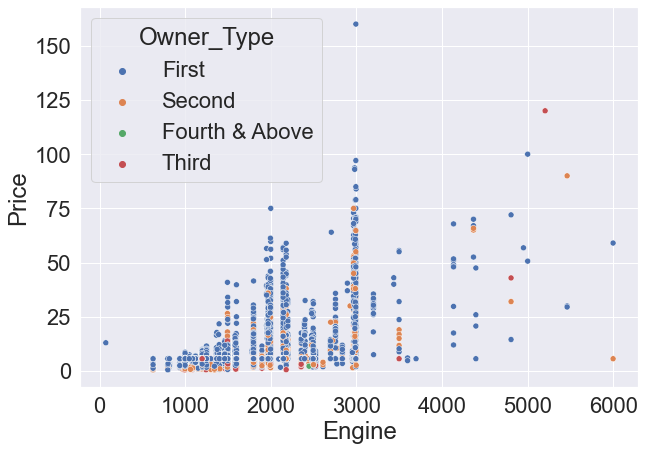

```python
# Explore relationship to Owner_Type between Engine vs. Price
plt.figure(figsize=(10, 7))
sns.scatterplot(y="Price", x="Engine", hue="Owner_Type", data=cars)
```

**Observations:**

- Like with power, first- and second-time owners cover the range of Engine vs. Price.
- Like with power, a cluster of third-time owners exists at the lower end of Engine and of Price.

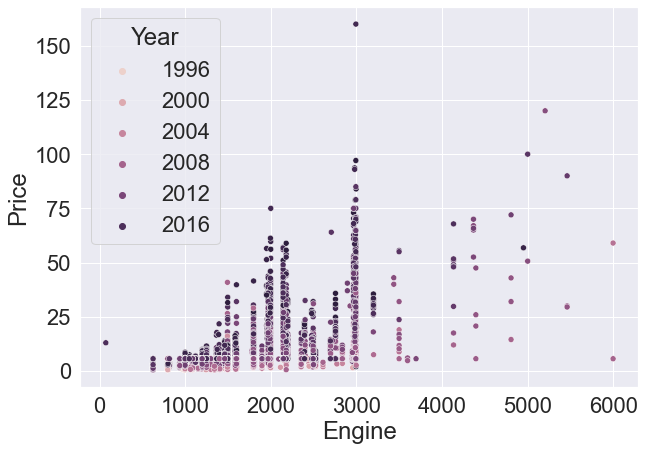

```python
# Explore relationship to Year between Engine vs. Price
plt.figure(figsize=(10, 7))
sns.scatterplot(y="Price", x="Engine", hue="Year", data=cars)
```

**Observation:**

- Newer cars cover the range of Engine vs. Price.
- Older cars tend to be less expensive and be lower in number of CC.

# 4 - Data Preprocessing (Part 2 of 2)

## 4.1 - Convert variables to categorical: Year, Fuel_Type, Transmission, Owner_Type, Seats, Brand, Location

```python
cars["Year"] = cars["Year"].astype("category")
cars["Fuel_Type"] = cars["Fuel_Type"].astype("category")
cars["Transmission"] = cars["Transmission"].astype("category")
cars["Owner_Type"] = cars["Owner_Type"].astype("category")
cars["Seats"] = cars["Seats"].astype("category")
cars["Brand"] = cars["Brand"].astype("category")
cars["Location"] = cars["Location"].astype("category")

# Choosing to drop the Model column to simplify analysis - over 2000 different types of models.
# With used cars, focus more on brand.
cars.drop(["Model"], axis=1, inplace=True)
```

## 4.2 - Encode Categorical Variables

```python
cars = pd.get_dummies(cars, columns=["Year"], drop_first=True)
cars = pd.get_dummies(cars, columns=["Fuel_Type"], drop_first=True)
cars = pd.get_dummies(cars, columns=["Transmission"], drop_first=True)
cars = pd.get_dummies(cars, columns=["Owner_Type"], drop_first=True)
cars = pd.get_dummies(cars, columns=["Seats"], drop_first=True)
cars = pd.get_dummies(cars, columns=["Brand"], drop_first=True)
cars = pd.get_dummies(cars, columns=["Location"], drop_first=True)
```

```python
# check for new columns
cars.info()
```

```
<class 'pandas.core.frame.DataFrame'>
RangeIndex: 7253 entries, 0 to 7252
Data columns (total 86 columns):
 #   Column                     Non-Null Count  Dtype
---  ------                     --------------  -----
 0   Kilometers_Driven          7253 non-null   int64
 1   Mileage                    7253 non-null   float64
 2   Engine                     7253 non-null   int64
 3   Power                      7253 non-null   float64
 4   Price                      7253 non-null   float64
 5   Year_1998                  7253 non-null   uint8
 6   Year_1999                  7253 non-null   uint8
 7   Year_2000                  7253 non-null   uint8
 8   Year_2001                  7253 non-null   uint8
 9   Year_2002                  7253 non-null   uint8
```

[output cut: 78 more lines]

## 4.3 - Transform Skewed Variables

The following variables are very skewed so I will transform them on a log scale: Kilometers_Driven, Engine, and Power.

```python
cols_to_log = ["Kilometers_Driven", "Engine", "Power"]

for colname in cols_to_log:
    cars[colname + "_log"] = np.log(cars[colname])
cars.drop(cols_to_log, axis=1, inplace=True)
```

```python
# Double-checking columns
cars.info()
```

```
<class 'pandas.core.frame.DataFrame'>
RangeIndex: 7253 entries, 0 to 7252
Data columns (total 86 columns):
 #   Column                     Non-Null Count  Dtype
---  ------                     --------------  -----
 0   Mileage                    7253 non-null   float64
 1   Price                      7253 non-null   float64
 2   Year_1998                  7253 non-null   uint8
 3   Year_1999                  7253 non-null   uint8
 4   Year_2000                  7253 non-null   uint8
 5   Year_2001                  7253 non-null   uint8
 6   Year_2002                  7253 non-null   uint8
 7   Year_2003                  7253 non-null   uint8
 8   Year_2004                  7253 non-null   uint8
 9   Year_2005                  7253 non-null   uint8
```

[output cut: 78 more lines]

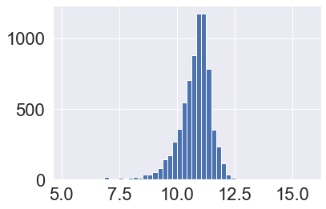

```python
# Double-checking Kilometers_Driven_log
plt.hist(cars["Kilometers_Driven_log"], 50)
plt.show()
```

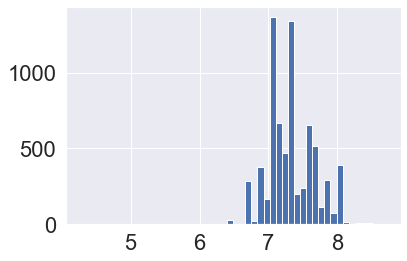

```python
# Double-checking Engine_log
plt.hist(cars["Engine_log"], 50)
plt.show()
```

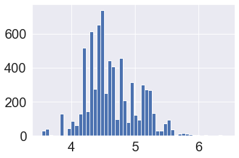

```python
# Double-checking Power_log
plt.hist(cars["Power_log"], 50)
plt.show()
```

## 4.4 - Treating Outliers

The columns with outliers were Kilometers_Driven, Engine, Power, and Price.

- I will plot the transformed columns Kilometers_Driven_log, Engine_log, and Power_log as boxplots to determine the status of their outliers.
- I want to leave Price untouched for now since it is the dependent variable (may decide differently in the course of modeling).

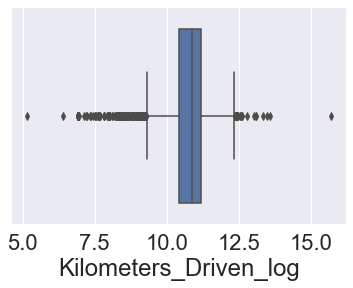

```python
sns.boxplot(x=cars["Kilometers_Driven_log"])
```

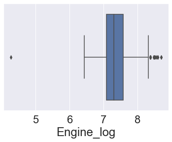

```python
sns.boxplot(x=cars["Engine_log"])
```

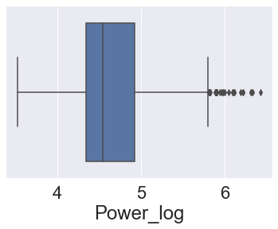

```python
sns.boxplot(x=cars["Power_log"])
```

After plotting the variables, will treat outliers with flooring and capping method.

```python
# Taking the following 2 functions from previous case study
def treat_outliers(df, col):
    """
    treats outliers in a variable
    col: str, name of the numerical variable
    df: dataframe
    col: name of the column
    """
    Q1 = df[col].quantile(0.25)  # 25th quantile
    Q3 = df[col].quantile(0.75)  # 75th quantile
    IQR = Q3 - Q1
    Lower_Whisker = Q1 - 1.5 * IQR
    Upper_Whisker = Q3 + 1.5 * IQR

    # all the values smaller than Lower_Whisker will be assigned the value of Lower_Whisker
    # all the values greater than Upper_Whisker will be assigned the value of Upper_Whisker
    df[col] = np.clip(df[col], Lower_Whisker, Upper_Whisker)

    return df


def treat_outliers_all(df, col_list):
    """
    treat outlier in all numerical variables
    col_list: list of numerical variables
    df: data frame
    """
    for c in col_list:
        df = treat_outliers(df, c)

    return df
```

```python
# Treat Outliers
numerical_col = ["Kilometers_Driven_log", "Engine_log", "Power_log"]
cars = treat_outliers_all(cars, numerical_col)
```

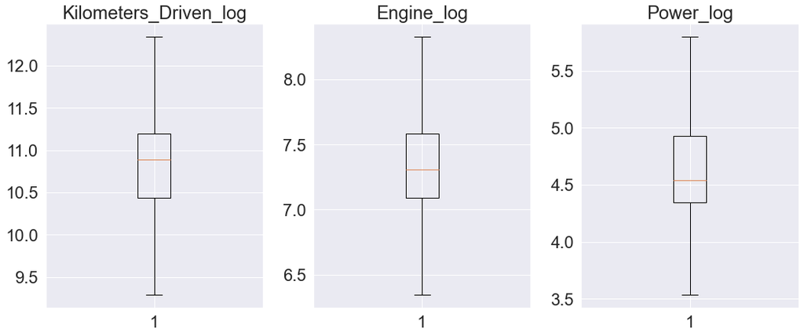

```python
# Check to see if outliers were treated
plt.figure(figsize=(20, 30))

for i, variable in enumerate(numerical_col):
    plt.subplot(5, 4, i + 1)
    plt.boxplot(cars[variable], whis=1.5)
    plt.tight_layout()
    plt.title(variable)

plt.show()
```

# 5 - Data Preparation for Modeling

```python
# defining X and y variables
X = cars.drop(["Price"], axis=1)
y = cars[["Price"]]
```

```python
X.head()
```

|  | Mileage | Year_1998 | Year_1999 | Year_2000 | Year_2001 | Year_2002 | Year_2003 | Year_2004 | Year_2005 | Year_2006 | Year_2007 | Year_2008 | Year_2009 | Year_2010 | Year_2011 | Year_2012 | Year_2013 | Year_2014 | Year_2015 | Year_2016 | Year_2017 | Year_2018 | Year_2019 | Fuel_Type_Diesel | Fuel_Type_Electric | Fuel_Type_LPG | Fuel_Type_Petrol | Transmission_Manual | Owner_Type_Fourth & Above | … |
| --- | --- | --- | --- | --- | --- | --- | --- | --- | --- | --- | --- | --- | --- | --- | --- | --- | --- | --- | --- | --- | --- | --- | --- | --- | --- | --- | --- | --- | --- | --- |
| 0 | 26.60 | 0 | 0 | 0 | 0 | 0 | 0 | 0 | 0 | 0 | 0 | 0 | 0 | 1 | 0 | 0 | 0 | 0 | 0 | 0 | 0 | 0 | 0 | 0 | 0 | 0 | 0 | 1 | 0 | … |
| 1 | 19.67 | 0 | 0 | 0 | 0 | 0 | 0 | 0 | 0 | 0 | 0 | 0 | 0 | 0 | 0 | 0 | 0 | 0 | 1 | 0 | 0 | 0 | 0 | 1 | 0 | 0 | 0 | 1 | 0 | … |
| 2 | 18.20 | 0 | 0 | 0 | 0 | 0 | 0 | 0 | 0 | 0 | 0 | 0 | 0 | 0 | 1 | 0 | 0 | 0 | 0 | 0 | 0 | 0 | 0 | 0 | 0 | 0 | 1 | 1 | 0 | … |
| 3 | 20.77 | 0 | 0 | 0 | 0 | 0 | 0 | 0 | 0 | 0 | 0 | 0 | 0 | 0 | 0 | 1 | 0 | 0 | 0 | 0 | 0 | 0 | 0 | 1 | 0 | 0 | 0 | 1 | 0 | … |
| 4 | 15.20 | 0 | 0 | 0 | 0 | 0 | 0 | 0 | 0 | 0 | 0 | 0 | 0 | 0 | 0 | 0 | 1 | 0 | 0 | 0 | 0 | 0 | 0 | 1 | 0 | 0 | 0 | 0 | 0 | … |

```python
y.head()
```

|  | Price |
| --- | --- |
| 0 | 1.75 |
| 1 | 12.50 |
| 2 | 4.50 |
| 3 | 6.00 |
| 4 | 17.74 |

```python
# split the data into train and test
from sklearn.model_selection import train_test_split

X_train, X_test, y_train, y_test = train_test_split(
    X, y, test_size=0.3, random_state=42
)
```

```python
X_train.head()
```

|  | Mileage | Year_1998 | Year_1999 | Year_2000 | Year_2001 | Year_2002 | Year_2003 | Year_2004 | Year_2005 | Year_2006 | Year_2007 | Year_2008 | Year_2009 | Year_2010 | Year_2011 | Year_2012 | Year_2013 | Year_2014 | Year_2015 | Year_2016 | Year_2017 | Year_2018 | Year_2019 | Fuel_Type_Diesel | Fuel_Type_Electric | Fuel_Type_LPG | Fuel_Type_Petrol | Transmission_Manual | Owner_Type_Fourth & Above | … |
| --- | --- | --- | --- | --- | --- | --- | --- | --- | --- | --- | --- | --- | --- | --- | --- | --- | --- | --- | --- | --- | --- | --- | --- | --- | --- | --- | --- | --- | --- | --- |
| 3181 | 22.50 | 0 | 0 | 0 | 0 | 0 | 0 | 0 | 0 | 0 | 0 | 0 | 0 | 0 | 0 | 0 | 0 | 1 | 0 | 0 | 0 | 0 | 0 | 0 | 0 | 0 | 1 | 1 | 0 | … |
| 952 | 13.68 | 0 | 0 | 0 | 0 | 0 | 0 | 0 | 0 | 0 | 0 | 0 | 0 | 0 | 0 | 0 | 0 | 0 | 0 | 0 | 0 | 1 | 0 | 1 | 0 | 0 | 0 | 1 | 0 | … |
| 2266 | 11.50 | 0 | 0 | 0 | 0 | 0 | 0 | 0 | 0 | 0 | 0 | 0 | 1 | 0 | 0 | 0 | 0 | 0 | 0 | 0 | 0 | 0 | 0 | 1 | 0 | 0 | 0 | 1 | 0 | … |
| 1504 | 20.77 | 0 | 0 | 0 | 0 | 0 | 0 | 0 | 0 | 0 | 0 | 0 | 0 | 0 | 0 | 0 | 0 | 0 | 0 | 0 | 1 | 0 | 0 | 1 | 0 | 0 | 0 | 1 | 0 | … |
| 7213 | 22.30 | 0 | 0 | 0 | 0 | 0 | 0 | 0 | 0 | 0 | 0 | 0 | 0 | 0 | 0 | 0 | 1 | 0 | 0 | 0 | 0 | 0 | 0 | 1 | 0 | 0 | 0 | 1 | 0 | … |

# 6 - Choose, train and evaluate the model

```python
# fitting the model on the train data (70% of the whole data)
from sklearn.linear_model import LinearRegression

linearregression = LinearRegression()
linearregression.fit(X_train, y_train)
```

```
LinearRegression()
```

```python
# Check the coefficients and intercept
coef_df = pd.DataFrame(
    np.append(linearregression.coef_[0], linearregression.intercept_[0]),
    index=X_train.columns.tolist() + ["Intercept"],
    columns=["Coefficients"],
)

coef_df
```

|  | Coefficients |
| --- | --- |
| Mileage | -9.739663e-02 |
| Year_1998 | -4.169020e-01 |
| Year_1999 | -5.825096e-01 |
| Year_2000 | 7.299627e-01 |
| Year_2001 | -4.676541e+00 |
| Year_2002 | -1.265252e+00 |
| Year_2003 | -3.784131e+00 |
| Year_2004 | -1.720190e+00 |
| Year_2005 | -2.714937e+00 |
| Year_2006 | -2.043069e+00 |
| Year_2007 | -1.918738e+00 |
| Year_2008 | -2.427552e+00 |
| Year_2009 | -2.443413e+00 |
| Year_2010 | -1.285628e+00 |
| Year_2011 | -1.162607e+00 |
| Year_2012 | -2.927038e-01 |
| Year_2013 | 4.960331e-01 |
| Year_2014 | 1.185338e+00 |
| Year_2015 | 2.181962e+00 |
| Year_2016 | 3.486700e+00 |
| Year_2017 | 4.948658e+00 |
| Year_2018 | 6.149338e+00 |
| Year_2019 | 7.556180e+00 |
| Fuel_Type_Diesel | 6.924726e-01 |
| Fuel_Type_Electric | 1.386120e+01 |
| Fuel_Type_LPG | 2.336240e+00 |
| Fuel_Type_Petrol | -2.983630e-01 |
| Transmission_Manual | 1.227007e-01 |
| Owner_Type_Fourth & Above | 1.190302e+00 |
| Owner_Type_Second | -3.304177e-01 |

[output cut: 56 more lines]

```python
# The next 2 functions are taken from a previous case study

# defining function for MAPE
def mape(targets, predictions):
    return np.mean(np.abs((targets - predictions)) / targets) * 100


# defining common function for all metrics
def model_perf(model, inp, out):
    """
    model: model
    inp: independent variables
    out: dependent variable
    """
    y_pred = model.predict(inp).flatten()
    y_act = out.values.flatten()

    return pd.DataFrame(
        {
            "MAE": mean_absolute_error(y_act, y_pred),
            "MAPE": mape(y_act, y_pred),
            "RMSE": np.sqrt(mean_squared_error(y_act, y_pred)),
            "R^2": r2_score(y_act, y_pred),
        },
        index=[0],
    )
```

```python
# Checking model performance on train set (seen 70% data)
print("Train Performance\n")
model_perf(linearregression, X_train, y_train)
```

```
Train Performance
```

|  | MAE | MAPE | RMSE | R^2 |
| --- | --- | --- | --- | --- |
| 0 | 3.315943 | 52.783014 | 6.215061 | 0.647909 |

```python
# Checking model performance on test set (unseen 30% data)
print("Test Performance\n")
model_perf(linearregression, X_test, y_test)
```

```
Test Performance
```

|  | MAE | MAPE | RMSE | R^2 |
| --- | --- | --- | --- | --- |
| 0 | 3.193643 | 54.325555 | 5.691886 | 0.666481 |

**Observations:**

# 7 - Linear Regression using statsmodels

## 7.1 - Build the Model

```python
import statsmodels.api as sm

# unlike sklearn, statsmodels does not add a constant to the data on its own
# we have to add the constant manually
X = sm.add_constant(X)
X_train1, X_test, y_train, y_test = train_test_split(
    X, y, test_size=0.3, random_state=42
)

olsmod0 = sm.OLS(y_train, X_train1)
olsres0 = olsmod0.fit()
print(olsres0.summary())
```

```
                            OLS Regression Results
==============================================================================
Dep. Variable:                  Price   R-squared:                       0.648
Model:                            OLS   Adj. R-squared:                  0.642
Method:                 Least Squares   F-statistic:                     113.5
Date:                Fri, 21 May 2021   Prob (F-statistic):               0.00
Time:                        20:48:20   Log-Likelihood:                -16480.
No. Observations:                5077   AIC:                         3.312e+04
Df Residuals:                    4995   BIC:                         3.366e+04
Df Model:                          81
Covariance Type:            nonrobust
=============================================================================================
                                coef    std err          t      P>|t|      [0.025      0.975]
---------------------------------------------------------------------------------------------
const                       -25.5962      8.185     -3.127      0.002     -41.642      -9.550
Mileage                      -0.0974      0.034     -2.834      0.005      -0.165      -0.030
Year_1998                    -1.5804      3.528     -0.448      0.654      -8.496       5.335
Year_1999                    -1.7460      4.274     -0.409      0.683     -10.124       6.632
Year_2000                    -0.4335      4.296     -0.101      0.920      -8.856       7.989
Year_2001                    -5.8400      2.813     -2.076      0.038     -11.354      -0.326
Year_2002                    -2.4287      1.598     -1.519      0.129      -5.562       0.705
Year_2003                    -4.9476      1.652     -2.994      0.003      -8.187      -1.708
Year_2004                    -2.8837      1.268     -2.274      0.023      -5.370      -0.397
Year_2005                    -3.8784      1.014     -3.823      0.000      -5.867      -1.890
Year_2006                    -3.2065      0.949     -3.378      0.001      -5.067      -1.346
Year_2007                    -3.0822      0.805     -3.830      0.000      -4.660      -1.505
Year_2008                    -3.5910      0.766     -4.688      0.000      -5.093      -2.089
Year_2009                    -3.6069      0.719     -5.017      0.000      -5.016      -2.198
Year_2010                    -2.4491      0.654     -3.744      0.000      -3.732      -1.167
Year_2011                    -2.3261      0.622     -3.742      0.000      -3.545      -1.107
Year_2012                    -1.4562      0.600     -2.427      0.015      -2.633      -0.280
Year_2013                    -0.6674      0.597     -1.119      0.263      -1.837       0.502
Year_2014                     0.0219      0.588      0.037      0.970      -1.130       1.174
Year_2015                     1.0185      0.591      1.724      0.085      -0.140       2.177
Year_2016                     2.3232      0.597      3.890      0.000       1.152       3.494
Year_2017                     3.7852      0.617      6.140      0.000       2.577       4.994
Year_2018                     4.9859      0.688      7.245      0.000       3.637       6.335
Year_2019                     6.3927      0.883      7.236      0.000       4.661       8.125
Fuel_Type_Diesel              0.6925      0.980      0.707      0.480      -1.229       2.614
Fuel_Type_Electric           13.8612      4.581      3.026      0.002       4.881      22.841
```

[output cut: 56 more lines]

```
Location_Pune                 0.6001      0.534      1.124      0.261      -0.447       1.647
Kilometers_Driven_log        -1.2848      0.206     -6.249      0.000      -1.688      -0.882
Engine_log                    4.0567      0.881      4.607      0.000       2.330       5.783
Power_log                     5.4550      0.640      8.519      0.000       4.200       6.710
==============================================================================
Omnibus:                     3575.177   Durbin-Watson:                   1.975
Prob(Omnibus):                  0.000   Jarque-Bera (JB):           332348.267
Skew:                           2.592   Prob(JB):                         0.00
Kurtosis:                      42.296   Cond. No.                     1.01e+16
==============================================================================

Notes:
[1] Standard Errors assume that the covariance matrix of the errors is correctly specified.
[2] The smallest eigenvalue is 2.64e-26. This might indicate that there are
strong multicollinearity problems or that the design matrix is singular.
```

## 7.2 - Test for Multicollinearity

```python
from statsmodels.stats.outliers_influence import variance_inflation_factor

vif_series1 = pd.Series(
    [variance_inflation_factor(X.values, i) for i in range(X.shape[1])], index=X.columns
)

print("VIF Scores: \n\n{}\n".format(vif_series1))
```

```
VIF Scores:

const                           0.000000
Mileage                         3.246585
Year_1998                            inf
Year_1999                            inf
Year_2000                            inf
Year_2001                            inf
Year_2002                            inf
Year_2003                            inf
Year_2004                            inf
Year_2005                            inf
Year_2006                            inf
Year_2007                            inf
Year_2008                            inf
Year_2009                            inf
Year_2010                            inf
Year_2011                            inf
Year_2012                            inf
Year_2013                            inf
Year_2014                            inf
Year_2015                            inf
Year_2016                            inf
Year_2017                            inf
Year_2018                            inf
Year_2019                            inf
Fuel_Type_Diesel               31.700417
Fuel_Type_Electric              1.048305
Fuel_Type_LPG                   1.217025
Fuel_Type_Petrol               32.273029
Transmission_Manual             2.302164
Owner_Type_Fourth & Above       1.039220
Owner_Type_Second               1.191666
Owner_Type_Third                1.155699
Seats_10.0                      9.149098
Seats_2.0                      19.410918
Seats_4.0                     120.546766
Seats_5.0                    1024.283543
Seats_6.0                      39.695520
Seats_7.0                     722.412387
```

[output cut: 34 more lines]

```
Brand_Volvo                    30.860903
Location_Bangalore              2.490866
Location_Chennai                2.969797
Location_Coimbatore             3.551301
Location_Delhi                  3.126834
Location_Hyderabad              3.733585
Location_Jaipur                 2.683988
Location_Kochi                  3.549853
Location_Kolkata                3.152915
Location_Mumbai                 3.973823
Location_Pune                   3.455110
Kilometers_Driven_log           2.148018
Engine_log                     11.664193
Power_log                       9.067815
dtype: float64
```

```python
# we drop the one with the highest vif values and check the adjusted R-squared
X_train2 = X_train1.drop("Brand_Maruti", axis=1)
vif_series2 = pd.Series(
    [variance_inflation_factor(X_train2.values, i) for i in range(X_train2.shape[1])],
    index=X_train2.columns,
)
print("VIF Scores: \n\n{}\n".format(vif_series2))
```

```
VIF Scores:

const                          0.000000
Mileage                        3.249658
Year_1998                           inf
Year_1999                           inf
Year_2000                           inf
Year_2001                           inf
Year_2002                           inf
Year_2003                           inf
Year_2004                           inf
Year_2005                           inf
Year_2006                           inf
Year_2007                           inf
Year_2008                           inf
Year_2009                           inf
Year_2010                           inf
Year_2011                           inf
Year_2012                           inf
Year_2013                           inf
Year_2014                           inf
Year_2015                           inf
Year_2016                           inf
Year_2017                           inf
Year_2018                           inf
Year_2019                           inf
Fuel_Type_Diesel              30.958963
Fuel_Type_Electric             1.068374
Fuel_Type_LPG                  1.278051
Fuel_Type_Petrol              31.523781
Transmission_Manual            2.327690
Owner_Type_Fourth & Above      1.065272
Owner_Type_Second              1.208724
Owner_Type_Third               1.173477
Seats_10.0                     7.199933
Seats_2.0                     11.324136
Seats_4.0                     90.023149
Seats_5.0                    734.411798
Seats_6.0                     32.847799
Seats_7.0                    516.582078
```

[output cut: 33 more lines]

```
Brand_Volvo                    1.099274
Location_Bangalore             2.492120
Location_Chennai               2.995869
Location_Coimbatore            3.627957
Location_Delhi                 3.156981
Location_Hyderabad             3.656117
Location_Jaipur                2.704442
Location_Kochi                 3.618780
Location_Kolkata               3.115546
Location_Mumbai                3.967976
Location_Pune                  3.389821
Kilometers_Driven_log          2.112481
Engine_log                    11.376418
Power_log                      8.844386
dtype: float64
```

```python
# we drop the one with the highest vif values and check the adjusted R-squared
X_train3 = X_train2.drop("Seats_7.0", axis=1)
vif_series3 = pd.Series(
    [variance_inflation_factor(X_train3.values, i) for i in range(X_train3.shape[1])],
    index=X_train3.columns,
)
print("VIF Scores: \n\n{}\n".format(vif_series3))
```

```
VIF Scores:

const                         0.000000
Mileage                       3.247653
Year_1998                          inf
Year_1999                          inf
Year_2000                          inf
Year_2001                          inf
Year_2002                          inf
Year_2003                          inf
Year_2004                          inf
Year_2005                          inf
Year_2006                          inf
Year_2007                          inf
Year_2008                          inf
Year_2009                          inf
Year_2010                          inf
Year_2011                          inf
Year_2012                          inf
Year_2013                          inf
Year_2014                          inf
Year_2015                          inf
Year_2016                          inf
Year_2017                          inf
Year_2018                          inf
Year_2019                          inf
Fuel_Type_Diesel             30.957926
Fuel_Type_Electric            1.068356
Fuel_Type_LPG                 1.278051
Fuel_Type_Petrol             31.514019
Transmission_Manual           2.327434
Owner_Type_Fourth & Above     1.065268
Owner_Type_Second             1.208640
Owner_Type_Third              1.173471
Seats_10.0                    1.104089
Seats_2.0                     1.199278
Seats_4.0                     1.665551
Seats_5.0                     3.161086
Seats_6.0                     1.331053
Seats_8.0                     1.301139
```

[output cut: 32 more lines]

```
Brand_Volvo                   1.099074
Location_Bangalore            2.492117
Location_Chennai              2.995869
Location_Coimbatore           3.627722
Location_Delhi                3.156973
Location_Hyderabad            3.655086
Location_Jaipur               2.704424
Location_Kochi                3.618668
Location_Kolkata              3.115512
Location_Mumbai               3.967976
Location_Pune                 3.389782
Kilometers_Driven_log         2.110436
Engine_log                   11.263766
Power_log                     8.743997
dtype: float64
```

```python
# we drop the one with the highest vif values and check the adjusted R-squared
X_train4 = X_train3.drop("Fuel_Type_Petrol", axis=1)
vif_series4 = pd.Series(
    [variance_inflation_factor(X_train4.values, i) for i in range(X_train4.shape[1])],
    index=X_train4.columns,
)
print("VIF Scores: \n\n{}\n".format(vif_series4))
```

```
VIF Scores:

const                         0.000000
Mileage                       3.135207
Year_1998                          inf
Year_1999                          inf
Year_2000                          inf
Year_2001                          inf
Year_2002                          inf
Year_2003                          inf
Year_2004                          inf
Year_2005                          inf
Year_2006                          inf
Year_2007                          inf
Year_2008                          inf
Year_2009                          inf
Year_2010                          inf
Year_2011                          inf
Year_2012                          inf
Year_2013                          inf
Year_2014                          inf
Year_2015                          inf
Year_2016                          inf
Year_2017                          inf
Year_2018                          inf
Year_2019                          inf
Fuel_Type_Diesel              2.698423
Fuel_Type_Electric            1.019301
Fuel_Type_LPG                 1.018218
Transmission_Manual           2.327154
Owner_Type_Fourth & Above     1.065264
Owner_Type_Second             1.208637
Owner_Type_Third              1.173397
Seats_10.0                    1.104089
Seats_2.0                     1.198901
Seats_4.0                     1.654994
Seats_5.0                     3.153521
Seats_6.0                     1.330973
Seats_8.0                     1.301124
Seats_9.0                     1.019266
```

[output cut: 31 more lines]

```
Brand_Volvo                   1.098854
Location_Bangalore            2.491969
Location_Chennai              2.994839
Location_Coimbatore           3.623919
Location_Delhi                3.156946
Location_Hyderabad            3.653437
Location_Jaipur               2.700878
Location_Kochi                3.618295
Location_Kolkata              3.113467
Location_Mumbai               3.967975
Location_Pune                 3.389758
Kilometers_Driven_log         2.102051
Engine_log                   11.135460
Power_log                     8.697777
dtype: float64
```

```python
# we drop the one with the highest vif values and check the adjusted R-squared
X_train5 = X_train4.drop("Engine_log", axis=1)
vif_series5 = pd.Series(
    [variance_inflation_factor(X_train5.values, i) for i in range(X_train5.shape[1])],
    index=X_train5.columns,
)
print("VIF Scores: \n\n{}\n".format(vif_series5))
```

```
VIF Scores:

const                        0.000000
Mileage                      2.890469
Year_1998                         inf
Year_1999                         inf
Year_2000                         inf
Year_2001                         inf
Year_2002                         inf
Year_2003                         inf
Year_2004                         inf
Year_2005                         inf
Year_2006                         inf
Year_2007                         inf
Year_2008                         inf
Year_2009                         inf
Year_2010                         inf
Year_2011                         inf
Year_2012                         inf
Year_2013                         inf
Year_2014                         inf
Year_2015                         inf
Year_2016                         inf
Year_2017                         inf
Year_2018                         inf
Year_2019                         inf
Fuel_Type_Diesel             2.234219
Fuel_Type_Electric           1.018982
Fuel_Type_LPG                1.017986
Transmission_Manual          2.327149
Owner_Type_Fourth & Above    1.063921
Owner_Type_Second            1.208593
Owner_Type_Third             1.173319
Seats_10.0                   1.098166
Seats_2.0                    1.196238
Seats_4.0                    1.627663
Seats_5.0                    2.983594
Seats_6.0                    1.330459
Seats_8.0                    1.297236
Seats_9.0                    1.018595
```

[output cut: 30 more lines]

```
Brand_Volkswagen             1.371038
Brand_Volvo                  1.098368
Location_Bangalore           2.491221
Location_Chennai             2.994804
Location_Coimbatore          3.623838
Location_Delhi               3.156926
Location_Hyderabad           3.653347
Location_Jaipur              2.700752
Location_Kochi               3.618169
Location_Kolkata             3.113301
Location_Mumbai              3.967593
Location_Pune                3.389451
Kilometers_Driven_log        2.099759
Power_log                    4.007786
dtype: float64
```

```python
# check the model
olsmod1 = sm.OLS(y_train, X_train5)
olsres1 = olsmod1.fit()
print(olsres1.summary())
```

```
                            OLS Regression Results
==============================================================================
Dep. Variable:                  Price   R-squared:                       0.646
Model:                            OLS   Adj. R-squared:                  0.641
Method:                 Least Squares   F-statistic:                     117.1
Date:                Fri, 21 May 2021   Prob (F-statistic):               0.00
Time:                        20:48:33   Log-Likelihood:                -16491.
No. Observations:                5077   AIC:                         3.314e+04
Df Residuals:                    4998   BIC:                         3.366e+04
Df Model:                          78
Covariance Type:            nonrobust
=============================================================================================
                                coef    std err          t      P>|t|      [0.025      0.975]
---------------------------------------------------------------------------------------------
const                       -10.8161      3.019     -3.582      0.000     -16.735      -4.897
Mileage                      -0.1396      0.032     -4.299      0.000      -0.203      -0.076
Year_1998                    -1.4042      3.521     -0.399      0.690      -8.307       5.498
Year_1999                    -1.1937      4.269     -0.280      0.780      -9.562       7.175
Year_2000                     0.2425      4.288      0.057      0.955      -8.163       8.648
Year_2001                    -5.0015      2.794     -1.790      0.074     -10.479       0.476
Year_2002                    -1.9102      1.566     -1.220      0.223      -4.981       1.161
Year_2003                    -4.1094      1.612     -2.550      0.011      -7.269      -0.950
Year_2004                    -2.2547      1.222     -1.845      0.065      -4.650       0.141
Year_2005                    -3.0245      0.949     -3.188      0.001      -4.884      -1.165
Year_2006                    -2.3956      0.877     -2.730      0.006      -4.116      -0.675
Year_2007                    -2.3591      0.723     -3.261      0.001      -3.777      -0.941
Year_2008                    -2.7372      0.671     -4.078      0.000      -4.053      -1.421
Year_2009                    -2.7919      0.619     -4.507      0.000      -4.006      -1.578
Year_2010                    -1.6982      0.548     -3.097      0.002      -2.773      -0.623
Year_2011                    -1.6091      0.514     -3.129      0.002      -2.617      -0.601
Year_2012                    -0.7800      0.499     -1.562      0.118      -1.759       0.199
Year_2013                    -0.0200      0.492     -0.041      0.968      -0.985       0.945
Year_2014                     0.6455      0.483      1.336      0.182      -0.302       1.593
Year_2015                     1.6671      0.485      3.440      0.001       0.717       2.617
Year_2016                     2.9428      0.495      5.950      0.000       1.973       3.912
Year_2017                     4.3665      0.523      8.350      0.000       3.341       5.392
Year_2018                     5.6108      0.604      9.286      0.000       4.426       6.795
Year_2019                     6.9979      0.822      8.510      0.000       5.386       8.610
Fuel_Type_Diesel              1.5415      0.264      5.844      0.000       1.024       2.059
Fuel_Type_Electric           13.7883      4.482      3.077      0.002       5.002      22.575
```

[output cut: 52 more lines]

```
Location_Mumbai              -0.3280      0.522     -0.629      0.530      -1.351       0.695
Location_Pune                 0.6240      0.535      1.166      0.244      -0.425       1.673
Kilometers_Driven_log        -1.2520      0.205     -6.096      0.000      -1.655      -0.849
Power_log                     7.6364      0.432     17.682      0.000       6.790       8.483
==============================================================================
Omnibus:                     3616.470   Durbin-Watson:                   1.970
Prob(Omnibus):                  0.000   Jarque-Bera (JB):           340829.883
Skew:                           2.637   Prob(JB):                         0.00
Kurtosis:                      42.791   Cond. No.                     3.74e+16
==============================================================================

Notes:
[1] Standard Errors assume that the covariance matrix of the errors is correctly specified.
[2] The smallest eigenvalue is 1.75e-27. This might indicate that there are
strong multicollinearity problems or that the design matrix is singular.
```

**Observations:**

- The p-values for non-categorical variables are all below 0.05 so no further columns need to be dropped.
- The R^2 is still at 0.65 as it was with the original model so the variables that were dropped did not affect the model that much.

## 7.3 - Test for Mean of Residuals

```python
residual = olsres1.resid
np.mean(residual)
```

```
1.3485756839690268e-13
```

**Observation:** Mean of residuals is very close to 0.

## 7.4 - Test for Linearity

```python
residual = olsres1.resid
fitted = olsres1.fittedvalues  # predicted values
```

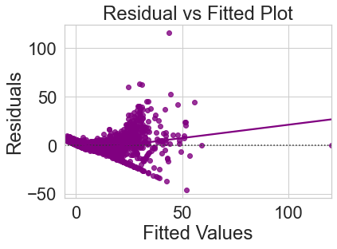

```python
sns.set_style("whitegrid")
sns.residplot(fitted, residual, color="purple", lowess=True)
plt.xlabel("Fitted Values")
plt.ylabel("Residuals")
plt.title("Residual vs Fitted Plot")
plt.show()
```

## 7.5 - Test for Normality

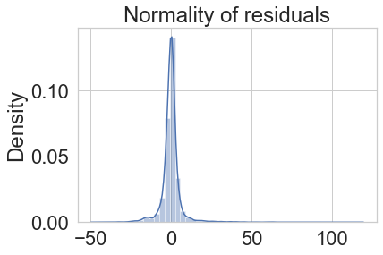

```python
sns.distplot(residual)
plt.title("Normality of residuals")
plt.show()
```

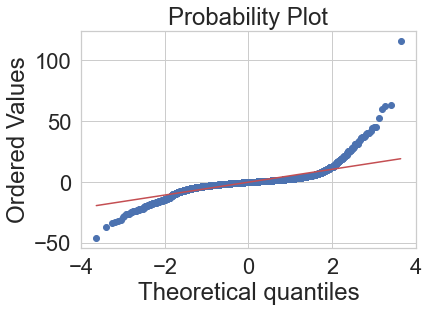

```python
import pylab
import scipy.stats as stats

stats.probplot(residual, dist="norm", plot=pylab)
plt.show()
```

## 7.6 - Test for Homoscedasticity

```python
import statsmodels.stats.api as sms
from statsmodels.compat import lzip

name = ["F statistic", "p-value"]
test = sms.het_goldfeldquandt(residual, X_train5)
lzip(name, test)
```

```
[('F statistic', 0.9640601701349686), ('p-value', 0.8180706119232194)]
```

**Observation:** Since the p-value is greater than 0.05, we can say that the residuals are homoscedastic.